# Basic & Convolutional Neural networks for Income Prediction & Image Classification

$Name$: Michael Simons

$Class$: CSE 474 - Machine Learning

$Date$: 6/27/2023

## Basic Neural Network

This section will aim to build and train a basic neural network using the income dataset. We will begin by analyzing and preprocessing the data, which comes in the form of a file titled `income_dataset.csv`.

```python
import numpy as np
import pandas as pd
import tensorflow as tf
income_data=pd.read_csv('income_dataset.csv') #Extract dataset
print(f'Entries: {income_data.shape[0]}, Features: {income_data.shape[1]}') #Show shape
income_data.head(4) #Examine first 4 entries
```

```
Entries: 32561, Features: 15
```

|  | age | workclass | fnlwgt | education | education.num | marital.status | occupation | relationship | race | sex | capital.gain | capital.loss | hours.per.week | native.country | income |
| --- | --- | --- | --- | --- | --- | --- | --- | --- | --- | --- | --- | --- | --- | --- | --- |
| 0 | 90 | ? | 77053 | HS-grad | 9 | Widowed | ? | Not-in-family | White | Female | 0 | 4356 | 40 | United-States | <=50K |
| 1 | 82 | Private | 132870 | HS-grad | 9 | Widowed | Exec-managerial | Not-in-family | White | Female | 0 | 4356 | 18 | United-States | <=50K |
| 2 | 66 | ? | 186061 | Some-college | 10 | Widowed | ? | Unmarried | Black | Female | 0 | 4356 | 40 | United-States | <=50K |
| 3 | 54 | Private | 140359 | 7th-8th | 4 | Divorced | Machine-op-inspct | Unmarried | White | Female | 0 | 3900 | 40 | United-States | <=50K |

The dataset consists of 32,561 row entries, each representing distinct individuals. Every entry contains 15 personal attributes related to the individual.

```python
income_data.dtypes #Examine data types
```

```
age                int64
workclass         object
fnlwgt             int64
education         object
education.num      int64
marital.status    object
occupation        object
relationship      object
race              object
sex               object
capital.gain       int64
capital.loss       int64
hours.per.week     int64
native.country    object
income            object
dtype: object
```

There are 9 features which are non-numerical **(workclass, education, marital status, occupation, relationship, race, sex, native country, income)** aswell as 6 features that are represented by integers: **(age, fnlwgt, education num, capital gain, capital loss, hours per week)**.

```python
income_data.describe() #Show statistics for numerical features
```

|  | age | fnlwgt | education.num | capital.gain | capital.loss | hours.per.week |
| --- | --- | --- | --- | --- | --- | --- |
| count | 32561.000000 | 3.256100e+04 | 32561.000000 | 32561.000000 | 32561.000000 | 32561.000000 |
| mean | 38.581647 | 1.897784e+05 | 10.080679 | 1077.648844 | 87.303830 | 40.437456 |
| std | 13.640433 | 1.055500e+05 | 2.572720 | 7385.292085 | 402.960219 | 12.347429 |
| min | 17.000000 | 1.228500e+04 | 1.000000 | 0.000000 | 0.000000 | 1.000000 |
| 25% | 28.000000 | 1.178270e+05 | 9.000000 | 0.000000 | 0.000000 | 40.000000 |
| 50% | 37.000000 | 1.783560e+05 | 10.000000 | 0.000000 | 0.000000 | 40.000000 |
| 75% | 48.000000 | 2.370510e+05 | 12.000000 | 0.000000 | 0.000000 | 45.000000 |
| max | 90.000000 | 1.484705e+06 | 16.000000 | 99999.000000 | 4356.000000 | 99.000000 |

The statistical description of the numerical features shows some notable results. The average age is about 38.6, with a standard deviation of 13.6. The average education level is relatively low, with a mean of 10.1 years. On average, individuals work 40.4 hours per week. A final observation of interest is that most individuals have no capital gains or losses. Let's see if any of the numerical features are meaningfully correlated with each other.

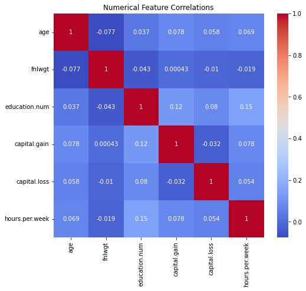

```python
import matplotlib.pyplot as plt
import seaborn as sns
plt.figure(figsize=(8, 7))
corr_matrix = income_data.corr()
sns.heatmap(corr_matrix, annot=True, cmap='coolwarm')
plt.title('Numerical Feature Correlations')
plt.show();
```

Observably, each of the numerical features seem to have rather low correlation with each other. Let's also develop an understanding of the categorical features in the dataset.

```python
#Define set of the 9 categorical features
categoricals=set(['workclass', 'education', 'marital.status', 'occupation', 'relationship', 'race', 'sex', 'native.country', 'income'])
for c in categoricals:
    print(f'Unique values in {c}: {income_data[c].unique()}\n') #For each feature, display the categories
```

```
Unique values in sex: ['Female' 'Male']

Unique values in native.country: ['United-States' '?' 'Mexico' 'Greece' 'Vietnam' 'China' 'Taiwan' 'India'
 'Philippines' 'Trinadad&Tobago' 'Canada' 'South' 'Holand-Netherlands'
 'Puerto-Rico' 'Poland' 'Iran' 'England' 'Germany' 'Italy' 'Japan' 'Hong'
 'Honduras' 'Cuba' 'Ireland' 'Cambodia' 'Peru' 'Nicaragua'
 'Dominican-Republic' 'Haiti' 'El-Salvador' 'Hungary' 'Columbia'
 'Guatemala' 'Jamaica' 'Ecuador' 'France' 'Yugoslavia' 'Scotland'
 'Portugal' 'Laos' 'Thailand' 'Outlying-US(Guam-USVI-etc)']

Unique values in marital.status: ['Widowed' 'Divorced' 'Separated' 'Never-married' 'Married-civ-spouse'
 'Married-spouse-absent' 'Married-AF-spouse']

Unique values in income: ['<=50K' '>50K']

Unique values in workclass: ['?' 'Private' 'State-gov' 'Federal-gov' 'Self-emp-not-inc' 'Self-emp-inc'
 'Local-gov' 'Without-pay' 'Never-worked']

Unique values in relationship: ['Not-in-family' 'Unmarried' 'Own-child' 'Other-relative' 'Husband' 'Wife']

Unique values in education: ['HS-grad' 'Some-college' '7th-8th' '10th' 'Doctorate' 'Prof-school'
 'Bachelors' 'Masters' '11th' 'Assoc-acdm' 'Assoc-voc' '1st-4th' '5th-6th'
 '12th' '9th' 'Preschool']

Unique values in race: ['White' 'Black' 'Asian-Pac-Islander' 'Other' 'Amer-Indian-Eskimo']

Unique values in occupation: ['?' 'Exec-managerial' 'Machine-op-inspct' 'Prof-specialty'
 'Other-service' 'Adm-clerical' 'Craft-repair' 'Transport-moving'
 'Handlers-cleaners' 'Sales' 'Farming-fishing' 'Tech-support'
 'Protective-serv' 'Armed-Forces' 'Priv-house-serv']
```

The native.country column appears to have a large number of unique values. Encoding this column would produce many additional features. We will drop the native.country column to keep things simple.

```python
income_data.drop(columns='native.country', inplace=True) #Remove column from dataframe
categoricals.remove('native.country') #Remove from previously defined set
print(categoricals) #Display new set of categories
```

```
{'sex', 'marital.status', 'income', 'workclass', 'relationship', 'education', 'race', 'occupation'}
```

We will now visualize the distribution of some of the categorical features in the data.

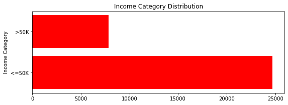

```python
count_incomes=income_data['income'].value_counts()
plt.figure(figsize=(9, 3))
plt.barh(count_incomes.index, count_incomes.values, color='r')
plt.ylabel('Income Category')
plt.title('Income Category Distribution')
plt.show();
```

The imbalance in the dataset's income category distribution is shown in the above bar graph, with nearly 25,000 indiviudals making 50K or less, and about 8,000 individuals making more than 50K.

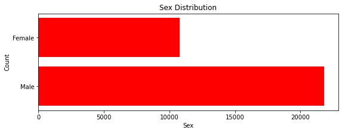

```python
count_sex = income_data['sex'].value_counts()
plt.figure(figsize=(9, 3))
plt.barh(count_sex.index, count_sex.values, color='r')
plt.title('Sex Distribution')
plt.xlabel('Sex')
plt.ylabel('Count')
plt.show();
```

The bar graph above shows the skew in the dataset's sex distribution, with about 11,000 female entries and nearly 22,000 male entries.

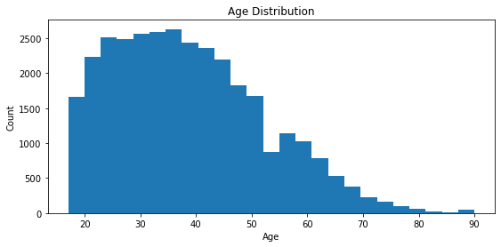

```python
plt.figure(figsize=(9, 4))
plt.hist(income_data['age'], bins=25)
plt.title('Age Distribution')
plt.xlabel('Age')
plt.ylabel('Count')
plt.show();
```

The histogram shows that an overwhelming majority of individuals in the dataset are between the age of 20 and 50, with a drastic decrease as the age increases.

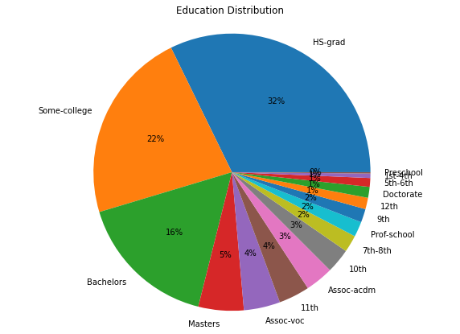

```python
count_educations = income_data['education'].value_counts()
plt.figure(figsize=(10, 7))
plt.pie(count_educations.values, labels=count_educations.index, autopct='%1.0f%%')
plt.title('Education Distribution')
plt.axis('equal')
plt.show();
```

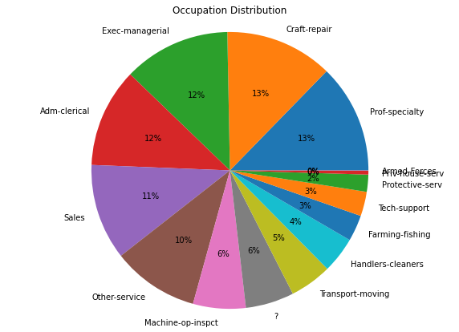

```python
count_occupation = income_data['occupation'].value_counts()
plt.figure(figsize=(10, 7))
plt.pie(count_occupation.values, labels=count_occupation.index, autopct='%1.0f%%')
plt.title('Occupation Distribution')
plt.axis('equal')
plt.show();
```

We will now shift the aim towards building a neural network which can predict someone's income class given their attributes. To prepare the data for training our neural network, we will encode the categorical values.

```python
categoricals.remove('income') #Remove target variable, it will be encoded separately
categoricals.remove('workclass') #Unexplored categorical feature
income_data['income']=income_data['income'].map({'<=50K': 0, '>50K': 1}) #Encode the target variable
income_data=pd.get_dummies(income_data,columns=list(categoricals)) #Encode the categorical input features
income_data.head(1)
```

|  | age | workclass | fnlwgt | education.num | capital.gain | capital.loss | hours.per.week | income | sex_Female | sex_Male | ... | occupation_Farming-fishing | occupation_Handlers-cleaners | occupation_Machine-op-inspct | occupation_Other-service | occupation_Priv-house-serv | occupation_Prof-specialty | occupation_Protective-serv | occupation_Sales | occupation_Tech-support | occupation_Transport-moving |
| --- | --- | --- | --- | --- | --- | --- | --- | --- | --- | --- | --- | --- | --- | --- | --- | --- | --- | --- | --- | --- | --- |
| 0 | 90 | ? | 77053 | 9 | 0 | 4356 | 40 | 0 | 1 | 0 | ... | 0 | 0 | 0 | 0 | 0 | 0 | 0 | 0 | 0 | 0 |

1 rows × 59 columns

We will now define the target and input features. Since the aim is to predict someone's income class, the target will be income, and the input features will be the rest of the data. After defining the targets and inputs, the data will be split into training and testing sets.

```python
targets=income_data['income'] #Define target column
inputs=income_data.drop(columns=['income','fnlwgt','education.num','workclass']) #Define input columns

split_idx=int(0.8 * income_data.shape[0]) #Compute 80% training/20% test split index

training_targets=targets[:split_idx] #80% training data
training_inputs=inputs[:split_idx]

testing_targets=targets[split_idx:]  #20% testing data
testing_inputs=inputs[split_idx:]

print(f'Training targets shape: {training_targets.shape}, Training inputs shape: {training_inputs.shape}')
print(f'Testing targets shape: {testing_targets.shape}, Testing inputs shape: {testing_inputs.shape}')
```

```
Training targets shape: (26048,), Training inputs shape: (26048, 55)
Testing targets shape: (6513,), Testing inputs shape: (6513, 55)
```

The neural network can now be built to predict the income category of an entry. We will a utilize fully-connected dense network with two hidden layers. We are using 55 input features, so the input dimension will be 55. The input layer will be of size 256, next hidden layer size 128, and the final hidden layer size 64. The output layer will be of size 1. The input layer and hidden layers will use ReLU activaton, and the output layer sigmoid activaton, as we are performing binary classification. Finally, the Adam optimizer will be used with a binary crossentropy loss function. We will begin training the model with 110 epochs, and visualize the results.

```python
from tensorflow.keras import models,layers,utils,optimizers
model=models.Sequential() #Initialize the model
model.add(layers.Dense(256, activation='relu', input_dim=training_inputs.shape[1])) #input layer, ReLU
model.add(layers.Dense(128, activation='relu')) #hidden layer, ReLU activation
model.add(layers.Dense(64, activation='relu')) #hidden layer, ReLU activation
model.add(layers.Dense(1, activation='sigmoid')) #Output layer, sigmoid activation
model.compile(optimizer=optimizers.Adam(),loss='binary_crossentropy',metrics=['accuracy']) #Compile using binary crossentropy
history=model.fit(training_inputs,training_targets,validation_data=(testing_inputs,testing_targets),epochs=110,batch_size=128) #Train the model for 110 epochs
```

The model is successfully trained. Let's visualize the results:

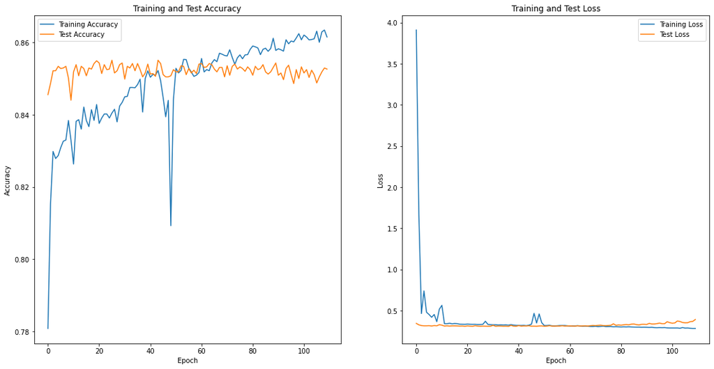

```python
plt.figure(figsize=(18,9))
plt.subplot(1,2,1)
plt.plot(history.history['accuracy'], label='Training Accuracy') #Plot the training accuracy at each epoch
plt.plot(history.history['val_accuracy'], label='Test Accuracy') #Plot the validation accuracy at each epoch
plt.title('Training and Test Accuracy')
plt.xlabel('Epoch')
plt.ylabel('Accuracy')
plt.legend()

plt.subplot(1,2,2)
plt.plot(history.history['loss'], label='Training Loss') #Plot the training loss at each epoch
plt.plot(history.history['val_loss'], label='Test Loss') #Plot the testing loss at each epoch
plt.title('Training and Test Loss')
plt.xlabel('Epoch')
plt.ylabel('Loss')
plt.legend()
plt.show();
```

The graph comparing the accuracy of the training and test data at each epoch indicates that training past 50 epochs is beginning to slightly overfit the model. This is because the test accuracy begins to slowly decrease as the training accuracy increases when the epoch passes a point between 50 and 60. A similar trend is shown in the graph comparing the training loss and test loss at each epoch, with the divergence beginning between epoch 50 and 60. Let's reset the model and train with 50 epochs instead.

```python
#Re-train the model with only 50 epochs.
model.reset_states() #Clear previous training
history=model.fit(training_inputs,training_targets,validation_data=(testing_inputs,testing_targets),epochs=50,batch_size=128)
```

```python
final_evaluation=model.evaluate(testing_inputs,testing_targets) #Evaluate final accuracy
print(f'Final accuracy on test data (50 epochs): {final_evaluation[1]}')
```

```
Final accuracy on test data (50 epochs): 0.8450790643692017
```

## Convolutional Neural Network

This section will aim to construct and train a convolutional neural network (CNN) which classifies an object based upon an image. Specifically, we will utilize the fashion MNIST dataset. The dataset contains 70,000 28x28 images of fashion-related objects, each associated with a label from a set of 10 possible classes. To begin, we will extract the dataset using the convenient methods included in the keras library.

```python
from keras.datasets import fashion_mnist
#Extract and split fashion dataset
(training_images, training_labels), (testing_images, testing_labels)=fashion_mnist.load_data()
print(f'Training images: {training_images.shape}\nTesting_images: {testing_images.shape}') #Show the shapes of each set
```

```
Training images: (60000, 28, 28)
Testing_images: (10000, 28, 28)
```

The keras library allowed us to easily extract and split the data into training and testing sets.

```python
set(training_labels)
```

```
{0, 1, 2, 3, 4, 5, 6, 7, 8, 9}
```

The label for each number is in the form of a number from 0 to 9. Let's visualize the distribution of each label in the training data.

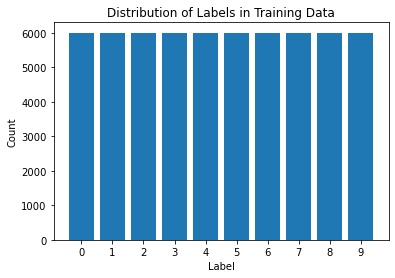

```python
from collections import Counter #Remembering Counters from MTH 448
label_counts=Counter(training_labels) #Count amount of images with each label
plt.bar(label_counts.keys(),label_counts.values()) #Fit counts nto bar plot
plt.xticks(np.arange(0,10)) #Label each bar
plt.xlabel('Label')
plt.ylabel('Count')
plt.title('Distribution of Labels in Training Data')
plt.show();
```

The bar graph shows that each of the labels have an equal distribution in the traning data. Some of the first entries in the data will now be displayed.

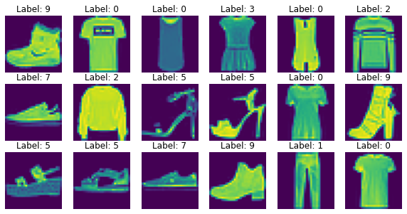

```python
plt.figure(figsize=(10,5))
for idx in range(0,18):
    plt.subplot(3,6,idx+1)
    plt.imshow(training_images[idx])
    plt.axis('off')
    plt.title(f'Label: {training_labels[idx]}')
plt.show;
```

Prior to building the CNN, we will normalize the pixel values of both the training and testing images. Dividing the pixel values by 255 will scale the values from the original range of 0-255 to a range of 0-1.

```python
training_images=training_images/255.0 #Re-scaling pixels
testing_images=testing_images/255.0
```

The aim is now to design the CNN. Using the sequential model included in the keras library will enable the addition of a sequence of layers.

```python
model=models.Sequential()
```

The CNN will be trained to classify the fashion images and predict their labels. Cross-entropy loss will be utilized for this task, and will use the keras adam optimizer. The network will begin with a short sequence of ReLU-activated convolutional layers. This choice of activation will prevent the vanishing gradient problem. The first layer will utilize 32 3x3 filters, and the second layer will utilize 64. Each filter will have a stride of 1.

```python
model.add(layers.Conv2D(filters=32, kernel_size=3,activation='relu', input_shape=(28, 28, 1))) #Input layer (Conv1)
model.add(layers.Conv2D(filters=64, kernel_size=3,activation='relu')) #Conv2
```

Following the convolutional layers, the network will utilize several regularization techniques such as batch normalization and dropout to prevent the model from overfitting. Max pooling will be used as a sub-sampling technique prior to flattening the data.

```python
model.add(layers.BatchNormalization()) #Normalization
model.add(layers.MaxPooling2D(pool_size=2)) #Sub-sampling
model.add(layers.Dropout(0.15)) #Regularization effect
model.add(layers.Flatten()) #Flatten data
```

Once the data has been flattened, it will pass through a fully-connected ReLU-activated layer consistng of 128 neurons. As a final regularizer, a dropout layer will be added. Past the dropout layer is the output layer, consisting of 10 neurons, each representing one of the labels 0-9. As this is a multi-class classification, softmax activation will be utilized to classify the label, returning a single prediction.

```python
model.add(layers.Dense(128, activation='relu')) #Fully-conntected layer
model.add(layers.Dropout(0.15)) #Final regularizer
model.add(layers.Dense(10, activation='softmax')) #Output layer
model.compile(optimizer=optimizers.Adam(), loss='categorical_crossentropy', metrics=['accuracy']) #Compile the structure
print(model.summary()) #Display the complete architecture
```

```
Model: "sequential_1"
_________________________________________________________________
 Layer (type)                Output Shape              Param #
=================================================================
 conv2d (Conv2D)             (None, 26, 26, 32)        320

 conv2d_1 (Conv2D)           (None, 24, 24, 64)        18496

 batch_normalization (BatchN  (None, 24, 24, 64)       256
 ormalization)

 max_pooling2d (MaxPooling2D  (None, 12, 12, 64)       0
 )

 dropout (Dropout)           (None, 12, 12, 64)        0

 flatten (Flatten)           (None, 9216)              0

 dense_4 (Dense)             (None, 128)               1179776

 dropout_1 (Dropout)         (None, 128)               0

 dense_5 (Dense)             (None, 10)                1290

=================================================================
Total params: 1,200,138
Trainable params: 1,200,010
Non-trainable params: 128
_________________________________________________________________
None
```

The model will now be trained for 10 epochs using the previously split MNIST training set, and the testing set for validation. Note that this will take up to several minutes.

```python
history=model.fit(training_images, utils.to_categorical(training_labels),
                    validation_data=(testing_images, utils.to_categorical(testing_labels)), epochs=10, batch_size=128)
```

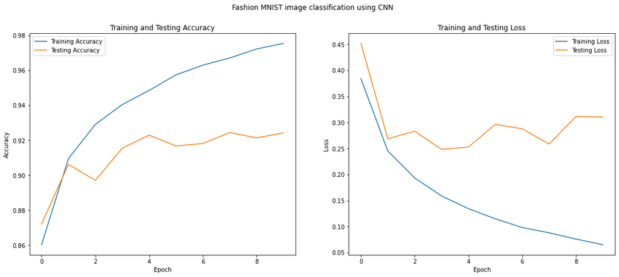

```python
plt.figure(figsize=(18, 7))
plt.suptitle('Fashion MNIST image classification using CNN')

plt.subplot(1, 2, 1)
plt.plot(history.history['accuracy'], label='Training Accuracy')
plt.plot(history.history['val_accuracy'], label='Testing Accuracy')
plt.title('Training and Testing Accuracy')
plt.xlabel('Epoch')
plt.ylabel('Accuracy')
plt.legend()

plt.subplot(1, 2, 2)
plt.plot(history.history['loss'], label='Training Loss')
plt.plot(history.history['val_loss'], label='Testing Loss')
plt.title('Training and Testing Loss')
plt.xlabel('Epoch')
plt.ylabel('Loss')
plt.legend()
plt.show()
```

Let's take note of the final achieved accuracy on the testing set.

```python
loss,accuracy=model.evaluate(testing_images,utils.to_categorical(testing_labels))
print(f'CNN Final Accuracy(10 epochs): {accuracy}')
```

```
CNN Final Accuracy(10 epochs): 0.9243000149726868
```

## References

[1] https://pandas.pydata.org/docs/reference/api/pandas.get_dummies.html

[2] https://matplotlib.org/stable/gallery/pie_and_polar_charts/pie_features.html

[3] https://docs.python.org/3/library/collections.html#counter-objects

[4] https://keras.io/api/models/sequential/

[5] https://keras.io/api/layers/

[6] https://keras.io/api/losses/

[7] https://keras.io/api/optimizers/adam/

[8] https://keras.io/api/datasets/fashion_mnist/